# Guía 16 Modelamiento predictivo: Regresión lineal

Diplomado en Análisis de Datos y Modelamiento Predictivo con Aprendizaje Automático para la Acuicultura.

Dr. José A. Gallardo y Dra. María Angélica Rueda.

Pontificia Universidad Católica de Valparaíso  
jose.gallardo@pucv.cl

17 June 2023

#### **Objetivos de aprendizaje**

Los objetivos de aprendizaje de esta guía son:

**1**. - Realizar validación leave-one-out a regresión lineal múltiple.

**2**. - Realizar gráficas avanzadas con ggplot2.

**3**. - Elaborar un reporte dinámico en formato html con **[Rmarkdown](https://rmarkdown.rstudio.com/)**.

## ESTUDIO DE CASO: TASA DE ACLARACIÓN (PROXY DE CONSUMO DE PARTÍCULAS).

[Ver estudio](https://drive.google.com/drive/u/2/folders/1QsVWwO44AT-Wl2nJ5jLV_lDSaB7W4J7d)

### **Ejercicio 1.** Elaborar y configurar Reporte en formato .Rmd

Elabore un documento .Rmd y configure su reporte para exportar en html. Instale solo los paquetes que utilice para el análisis de los datos.

```r
knitr::opts_chunk$set(echo = TRUE)
library(readxl)
library(ggplot2)
library(dplyr)
library(multcomp)
library(psych)
library(car)
library(caret)
library(lmtest)
library(pander)
library(ggpmisc)
library(gridExtra)
library(ggpubr)
library(knitr)
```

Ejecute cada uno de los siguientes ejercicios en uno o más bloques de códigos diferentes. Sea ordenado y documente su reporte adecuadamente.

### **Ejercicio 2.** Modelamiento predictivo.

Importe el set de datos **ParticleClearance.xlsx** que está en la hoja 1, nombre el objeto como clearance. Transformar a factor la variable Sample.

Realizar:

**a).** Seleccione las variables **time,sample, microparticle_concentration, log_microparticle_concentration** de la base de datos clearance.

```r
# Cargar la base de datos
clearance <-  read_excel("ParticleClearance.xlsx", sheet = 1)
clearance$sample <- as.factor(clearance$sample)


clearance <- clearance[, c("time","sample","microparticle_concentration","log_microparticle_concentration")]
```

**b).** Ajuste el modelo de regresión múltiple con lm(). Donde la variable respuesta es log_microparticle_concentration y las variables predictoras son time, sample e interacción time*sample. Llame al modelo lm.full

```r
lm.full <- lm(log_microparticle_concentration
              ~ time + sample+ time*sample,
              data = clearance)
```

**c).** Generar vector vacío para guardar los resultados de la validación leave-one-out.

```r
validation_results <- vector("numeric", length = nrow(clearance))
```

**d).** Realizar validación leave-one-out.

```r
for (i in 1:nrow(clearance)) {
  # Obtener el conjunto de entrenamiento
  train_data <- clearance[-i, ]

  # Obtener el conjunto de prueba
  test_data <- clearance[i, ]

  # Ajustar el modelo de regresión múltiple en el conjunto de entrenamiento
  lm_model <- lm(log_microparticle_concentration ~ time*sample + time + sample, data = train_data)

  # Realizar predicciones en el conjunto de prueba
  predictions <- predict(lm_model, newdata = test_data)

  # Calcular el error de prueba (RMSE)
  rmse <- sqrt(mean((test_data$log_microparticle_concentration - predictions)^2))

  # Guardar el error en el vector de resultados
  validation_results[i] <- rmse
}
```

**e).** Calcule el promedio del RMSEy redondee el valor a dos cifras.

```r
average_rmse <- round(mean(validation_results),2)
```

**f).** Genere un dataframe con los Fold y los valores de RMSE obtenidos en la validación leave-one-out.

```r
results_df <- data.frame(Fold = 1:nrow(clearance), RMSE = validation_results)
```

**c).** Realice un gráfico de líneas y puntos con ggplot2. Donde en el eje x estén los Folds y en el eje y estén los valores de RMSE de la validación leave-one-out. Además, que muestre con líneas punteadas rojas el promedio del RMSE. Exporte la figura como archivo .jpeg.

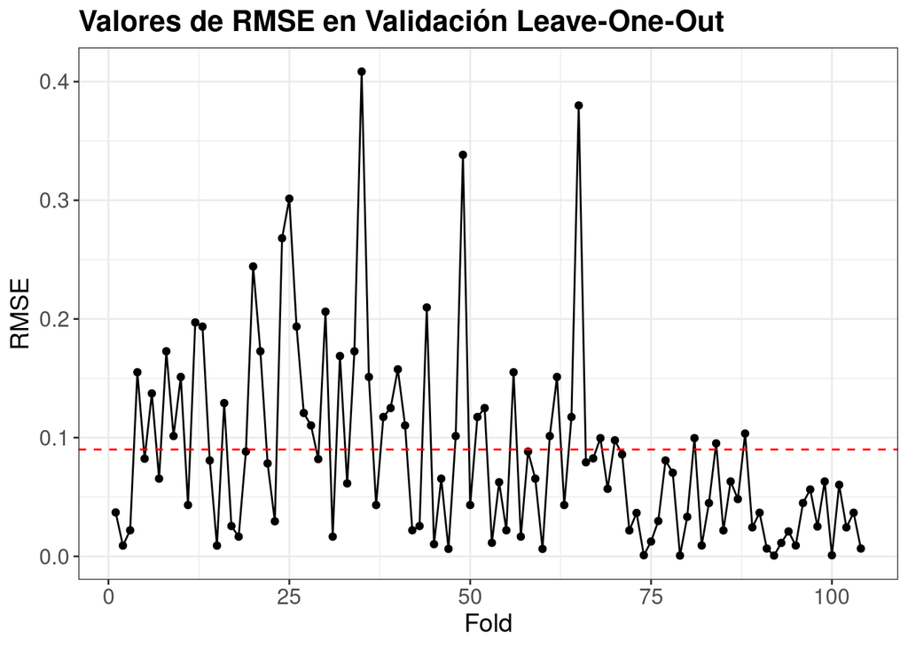

```r
#jpeg(file = "LOO.jpg",
#     width = 60, height = 20,
#     units = "cm",
#     quality = 95,
#     res = 300)
ggplot(results_df, aes(x = Fold, y = RMSE)) +
  geom_line() +
  geom_point() +
  geom_hline(yintercept = average_rmse, linetype = "dashed", color = "red") +
  xlab("Fold") +
  ylab("RMSE") +
  ggtitle("Valores de RMSE en Validación Leave-One-Out") +
  theme_bw() +
  theme(plot.title = element_text(size = 16, face = "bold"),
        axis.title = element_text(size = 14),
        axis.text = element_text(size = 12))
```

```r
#dev.off()
```